# Homework 8

Ismam Ferdous

2025-10-31

Each question worth 1 pt, except 3d which is 2pts.

## Q1

You buy a special 6-sided die for a magic trick that’s weighted such that getting a 6 is twice as likely as any other number (i.e. P(6) = 2*P(k) for k=1,2…5). Let X be the result of rolling this die once.

1. What is the PMF of X?
2. Plot the PMF of X.
3. Find the expectation of X.
4. Find the variance and SD of X.
5. Empirically check the E, Var, and SD you just found by simulating drawing a large sample and finding the mean, var, and SD of your sample. (use the `sample()` function with the `prob` argument, see help page or https://www.r-bloggers.com/2024/03/mastering-random-sampling-in-r-with-the-sample-function for more info.)

```r
library(tidyverse)


# finding the PMF of x :

die_faces <- 1:6
prob <- rep(1, 6)    # Start with 1 for each face
prob[6] <- 2         # Make the 6 twice as likely
prob <- prob / sum(prob) # Normalize so it sums to 1

# create the table :

pmf_df <- data.frame(Face = die_faces, Probability = prob)
pmf_df
```

```
##   Face Probability
## 1    1   0.1428571
## 2    2   0.1428571
## 3    3   0.1428571
## 4    4   0.1428571
## 5    5   0.1428571
## 6    6   0.2857143
```

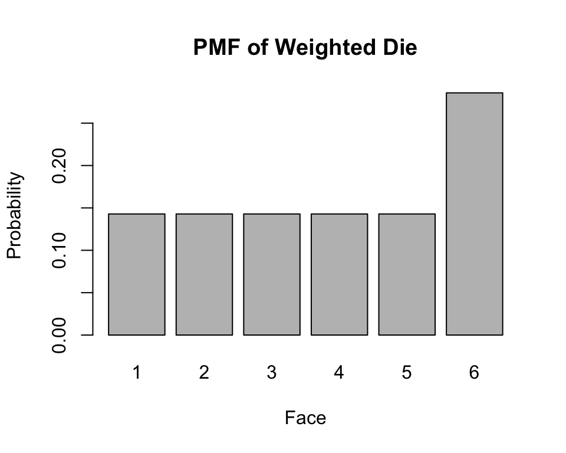

```r
# plotting :
barplot(prob,
        names.arg = die_faces,
        main = "PMF of Weighted Die",
        xlab = "Face",
        ylab = "Probability")
```

```r
# expectations of x :

expected_value <- sum(die_faces * prob)
print(expected_value)
```

```
## [1] 3.857143
```

```r
# var and sd :
variance <- sum((die_faces - expected_value)^2 * prob)
sd_value <- sqrt(variance)
print(variance)
```

```
## [1] 3.265306
```

```r
print(sd_value)
```

```
## [1] 1.807016
```

```r
# simulate to check

samples = sample(1:6, 1e5, replace=TRUE, prob=prob)
mean(samples)
```

```
## [1] 3.85467
```

```r
var(samples)
```

```
## [1] 3.263122
```

```r
sd(samples)
```

```
## [1] 1.806411
```

## Q2

In Sunnyville, all year round on any given day there’s a 95% chance it’s sunny. Suppose additionally that being sunny and being rainy are mutually exclusive events in Sunnyville on a given day, and that each day’s weather is independent of every other day.

1. Specify a binomial RV model for the total number of days of sun in a year.
2. Show a plot of the PMF. Adjust the range so it shows only outcomes where the probability bar is visible.
3. What are the EV, Var, and SD of this variable? You can use any formula you like.
4. According to your model, what is the probability of observing fewer than 10 days of rain in a year?
5. According to your model, what is the probability of observing fewer than 93% of days of sun in a year?

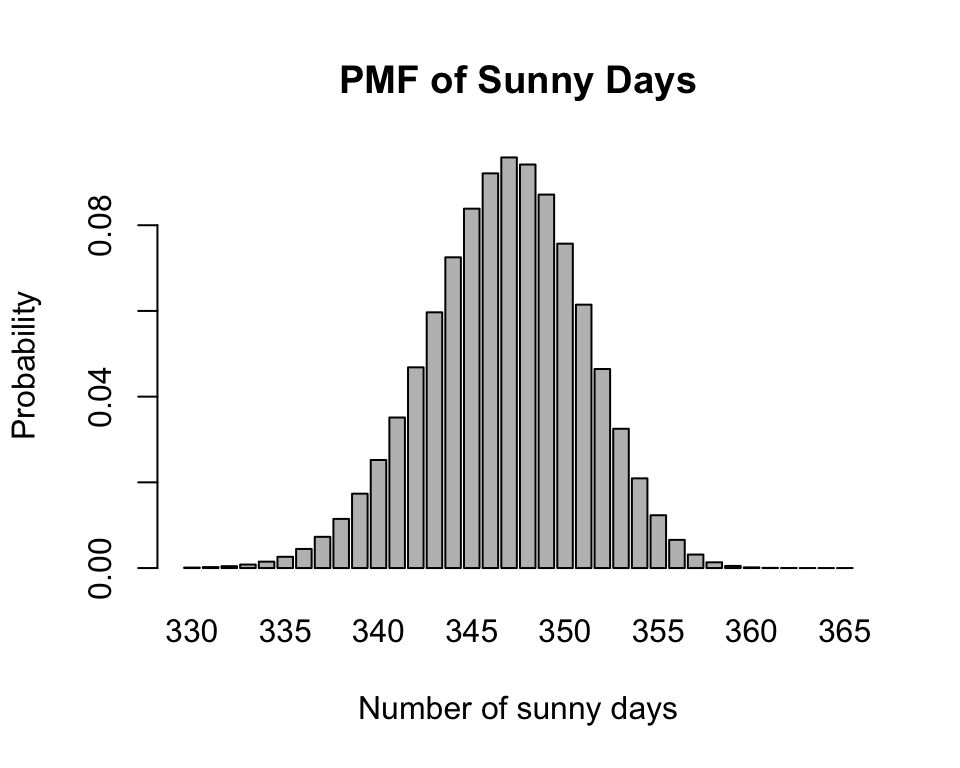

```r
# specifying :
n = 365
p = 0.95

# plot the pmf :

x_values = 330:365
pmf = dbinom(x_values, size=n, prob=p)
barplot(pmf, names.arg=x_values, main="PMF of Sunny Days", xlab="Number of sunny days", ylab="Probability")
```

```r
# var, sd, expected value :

EV = n * p
Var = n * p * (1-p)
SD = sqrt(Var)

EV
```

```
## [1] 346.75
```

```r
Var
```

```
## [1] 17.3375
```

```r
SD
```

```
## [1] 4.163832
```

```r
# what is the probability of observing fewer than 10 days of rain :

# atleast 355
prob_10_rain = 1 - pbinom(355, size=n, prob=p)
prob_10_rain
```

```
## [1] 0.01176903
```

```r
#Probability of Fewer Than 93% Sunny Days
# - 0.93 × 365 ~ 339.45

prob_less_93_sun = pbinom(339, size=n, prob=p)
prob_less_93_sun
```

```
## [1] 0.0463851
```

## Q3

Recall from section 10.3.1 in the notes the PMF for the sum of rolling a pair of fair 6-sided dice:

```
P(X=k)=(6−|k−7|)/36 for k=2,3,...,12
```

What’s the probability of each of the following events?

1. Getting an even sum.
2. Getting a sum that’s not 7.
3. In 15 rolls, not getting a sum of 7 even once.
4. In 36 rolls, getting snake eyes (i.e. double 1) at least once. (hint: first find the probability of the opposite, i.e. not getting a single time, then subtract from 1)

```r
# a. even sum

pmf = function(k) (6 - abs(k - 7)) / 36
even_sums = seq(2, 12, 2)
prob_even_sum = sum(sapply(even_sums, pmf))
prob_even_sum
```

```
## [1] 0.5
```

```r
# b. making sure its not 7 :

prob_not_7 = 1 - pmf(7)
prob_not_7
```

```
## [1] 0.8333333
```

```r
#c. In 15 rolls, not seeing a sum of 7 even once :

p7 = pmf(7)
prob_no_7_in15 = (1 - p7)^15
prob_no_7_in15
```

```
## [1] 0.06490547
```

```r
#d. snake eyes in 36 rolls :

# probability of this happening is 1/36 :

# probability of not getting in 36 rolls (35/36)^36

prob_no_snakeeyes_36 = (35/36)^36
prob_atleast1_snakeeyes = 1 - prob_no_snakeeyes_36
prob_atleast1_snakeeyes
```

```
## [1] 0.63729
```